**City College of San Francisco**

MATH 108 - Foundations of Data Science

# Lecture 17: Distributions

Associated Textbook Sections: [10.1, 10.2, 10.3, and 10.4](https://inferentialthinking.com/chapters/10/1/Empirical_Distributions.html)

**City College of San Francisco**

MATH 108 - Foundations of Data Science

## Outline

- Distributions
- Law of Large Numbers
- A Statistic

## Set Up the Notebook

```python
from datascience import *
import numpy as np
%matplotlib inline
import matplotlib.pyplot as plt
plt.style.use('fivethirtyeight')
```

## Distributions

### Probability Distribution

- Random quantity with various possible values
- Probability Distribution:
  - All the possible values of the quantity
  - The probability of each of those values
- If you can do the math, you can work out the probability distribution without ever simulating it
- But... simulation is often easier!

### Empirical Distribution

- Empirical: based on observations
- Observations can be from repetitions of an experiment
- Empirical Distribution:
  - All observed values
  - The proportion of times each value appears

### Demo: Distributions

Create a table with the face numbers of a six-sided die. Use that table with the `sample` method to simulate randomly rolling a die. Visualize the empirical distribution.

```python
die = Table().with_column('Face', np.arange(1, 7))
die
```

| Face |
| --- |
| 1 |
| 2 |
| 3 |
| 4 |
| 5 |
| 6 |

```python
die.sample(10)
```

| Face |
| --- |
| 1 |
| 4 |
| 3 |
| 1 |
| 5 |
| 6 |
| 6 |
| 3 |
| 4 |
| 5 |

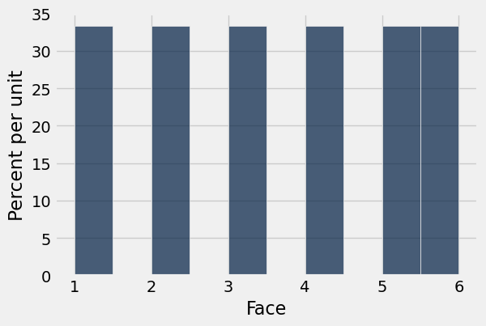

```python
die.hist()  # look at theoretical probability distribution
```

Update the bins and randomly sample for a few different sample sizes.

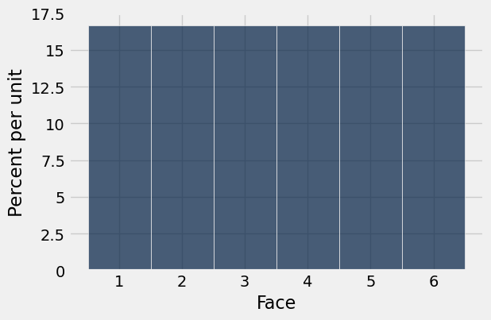

```python
roll_bins = np.arange(0.5, 6.6, 1)    # just to make it look better.
die.hist(bins=roll_bins)
```

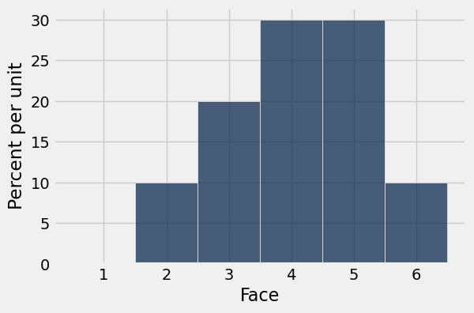

```python
# look at experimental probability distribution (start with smaller n and then increse)

die.sample(10).hist(bins=roll_bins)
```

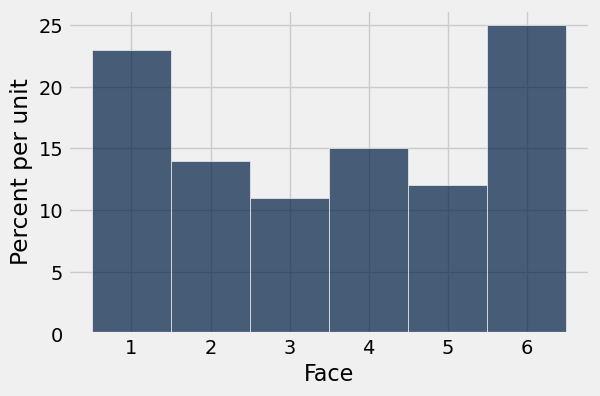

```python
die.sample(100).hist(bins=roll_bins)
```

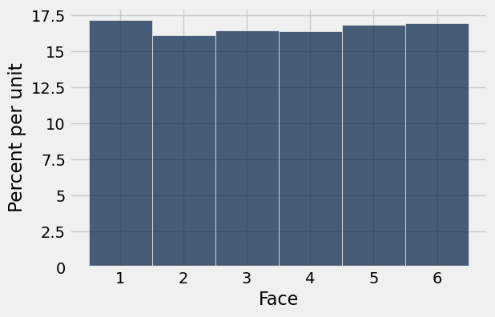

```python
die.sample(10000).hist(bins=roll_bins)
```

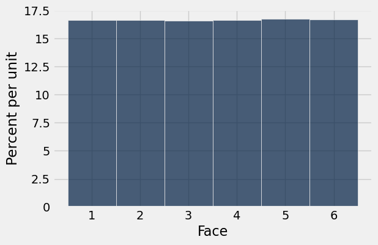

```python
die.sample(100000).hist(bins=roll_bins)
```

## Law of Large Numbers

### Law of Averages / Law of Large Numbers

- If a chance experiment is repeated many times, independently and under the same conditions, then the proportion of times that an event occurs gets closer to the theoretical probability of the event
- As you increase the number of rolls of a six-sided die, the proportion of times you see the face with five spots gets closer to 1/6

### Empirical Distribution of a Sample

If the sample size is large, then the empirical distribution of a uniform random sample resembles the distribution of the population, with high probability.

### Demo: Large Random Samples

Load the flight delay data in `delay_july_2022.csv` sourced from the [Bureau of Transportation Statistics's Airline On-Time Performance Data](https://www.transtats.bts.gov/Tables.asp?QO_VQ=EFD&QO_anzr=Nv4yv0r%FDb0-gvzr%FDcr4s14zn0pr%FDQn6n&QO_fu146_anzr=b0-gvzr)

```python
delays = Table.read_table('./data/delays_july_2022.csv')
delays
```

| MONTH | FL_DATE | OP_UNIQUE_CARRIER | ORIGIN | DEST | ARR_DELAY |
| --- | --- | --- | --- | --- | --- |
| 7 | 7/13/2022 12:00:00 AM | WN | FLL | BWI | 36 |
| 7 | 7/13/2022 12:00:00 AM | WN | FLL | CMH | -15 |
| 7 | 7/13/2022 12:00:00 AM | WN | FLL | DAL | -3 |
| 7 | 7/13/2022 12:00:00 AM | WN | FLL | DAL | -27 |
| 7 | 7/13/2022 12:00:00 AM | WN | FLL | DCA | -2 |
| 7 | 7/13/2022 12:00:00 AM | WN | FLL | DCA | -12 |
| 7 | 7/13/2022 12:00:00 AM | WN | FLL | HOU | 6 |
| 7 | 7/13/2022 12:00:00 AM | WN | FLL | HOU | -12 |
| 7 | 7/13/2022 12:00:00 AM | WN | FLL | HOU | 8 |
| 7 | 7/13/2022 12:00:00 AM | WN | FLL | IND | 9 |

... (594947 rows omitted)

Narrow the data to flights that have left from SFO.

```python
sfo_delays = delays.where('ORIGIN', 'SFO').drop(0, 1, 3).relabeled('ARR_DELAY', 'DELAY')
sfo_delays
```

| OP_UNIQUE_CARRIER | DEST | DELAY |
| --- | --- | --- |
| WN | BUR | -18 |
| WN | BUR | -13 |
| WN | BUR | -7 |
| WN | BUR | -6 |
| WN | BUR | -16 |
| WN | BUR | nan |
| WN | DEN | -18 |
| WN | DEN | -14 |
| WN | DEN | 66 |
| WN | LAS | 10 |

... (11806 rows omitted)

Remove `nan` values from the data set.

```python
sfo_delays = sfo_delays.sort('DELAY', True)
sfo_delays
```

| OP_UNIQUE_CARRIER | DEST | DELAY |
| --- | --- | --- |
| WN | BUR | nan |
| WN | DEN | nan |
| WN | DEN | nan |
| WN | MDW | nan |
| WN | BUR | nan |
| WN | DEN | nan |
| WN | DEN | nan |
| WN | LAS | nan |
| WN | PHX | nan |
| WN | LAS | nan |

... (11806 rows omitted)

**You are not responsible for understanding how to make the nan filter.**

```python
nan_filter = np.invert(np.isnan(sfo_delays.column('DELAY')))
nan_filter
```

```
array([False, False, False, ...,  True,  True,  True], dtype=bool)
```

```python
sfo_delays = sfo_delays.where(nan_filter)
sfo_delays
```

| OP_UNIQUE_CARRIER | DEST | DELAY |
| --- | --- | --- |
| F9 | LAS | 1311 |
| AA | MIA | 1264 |
| OO | BIH | 1227 |
| UA | DEN | 1217 |
| F9 | DFW | 1197 |
| AA | ORD | 1085 |
| AA | DFW | 1073 |
| UA | AUS | 994 |
| UA | IAH | 987 |
| F9 | LAS | 960 |

... (11651 rows omitted)

Visualize the distribution of flight delays in the delay data.

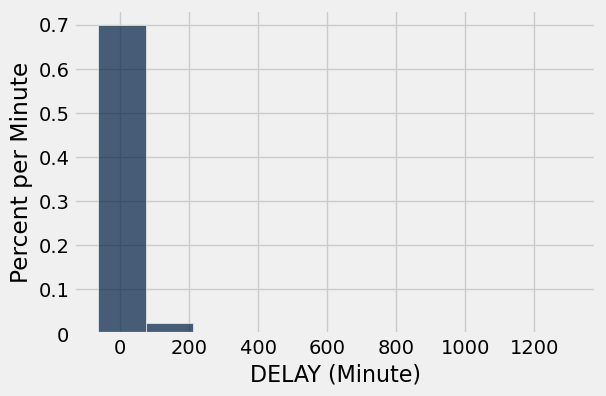

```python
sfo_delays.hist('DELAY', unit='Minute')
```

```python
min(sfo_delays.column('DELAY'))
```

```
-64.0
```

```python
max(sfo_delays.column('DELAY'))
```

```
1311.0
```

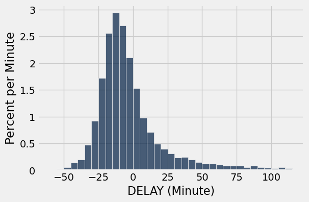

```python
bins = np.arange(-60, 120, 5)
sfo_delays.hist('DELAY', bins = bins, unit='Minute')
```

```python
np.average(sfo_delays.column('DELAY'))
```

```
1.0869565217391304
```

```python
np.median(sfo_delays.column('DELAY'))
```

```
-9.0
```

Randomly sample 10 and 1000 flights from the delay data and visualize the distributions of the samples.

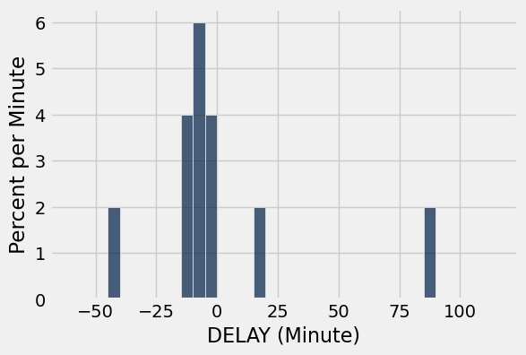

```python
sfo_delays.sample(10).hist('DELAY', bins = bins, unit='Minute')
```

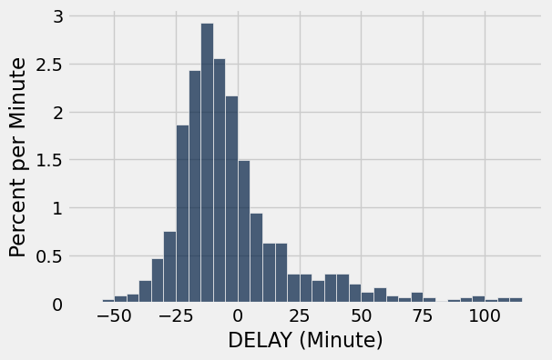

```python
sfo_delays.sample(1000).hist('DELAY', bins = bins, unit='Minute')
```

## A Statistic

### Inference

- Statistical Inference: Making conclusions based on data in random samples
- Example: Use the data to guess the value of an unknown and fixed number by creating an estimate of the unknown quantity that depends on the random sample.

### Terminology

- Parameter: A number associated with the population
- Statistic: A number calculated from the sample
- A statistic can be used as an estimate of a parameter

### Demo: Simulating Statistics

Calculate the median parameter for the flight delays and compare it to the median statistic associated with a random sample of 10 flights.

```python
np.median(sfo_delays.column('DELAY'))
```

```
-9.0
```

```python
np.median(sfo_delays.sample(10).column('DELAY'))
```

```
-12.5
```

Define a function that randomly samples delay data for an inputted sample size and returns the median delay for that sample.

```python
def sample_median(size):
    return np.median(sfo_delays.sample(size).column('DELAY'))
```

```python
sample_median(10)
```

```
-11.5
```

Simulate randomly sampling 10 flights 1000 times and storing the sample delay medians for each iteration. Add the results to a table and visualize the sampling distribution.

```python
sample_medians = make_array()     # initialize the array

for _ in np.arange(1000):
    new_median = sample_median(10)
    sample_medians = np.append(sample_medians, new_median)
```

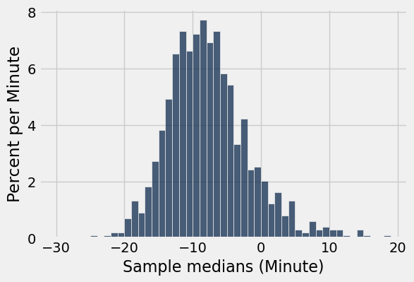

```python
Table().with_column('Sample medians', sample_medians).hist(bins = np.arange(-30,20), unit='Minute')
```

Repeat the sample simulation except use a sample size of 1000, instead of 10.

```python
sample_medians = make_array()     # initialize the array

for _ in np.arange(1000):
    new_median = sample_median(1000)
    sample_medians = np.append(sample_medians, new_median)
```

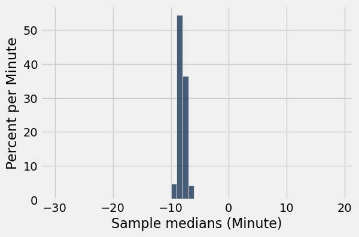

```python
Table().with_column('Sample medians', sample_medians).hist(bins = np.arange(-30,20), unit='Minute')
```

### Probability Distribution of a Statistic

- Values of a statistic vary because random samples vary
- Sampling distribution (or probability distribution) of the statistic:
  - All possible values of the statistic,
  - and all the corresponding probabilities
  - Can be hard to calculate
    - Either have to do the math
    - Or have to generate all possible samples and calculate the statistic based on each sample

### Empirical Distribution of a Statistic

- Empirical distribution of the statistic:
  - Based on simulated values of the statistic
  - Consists of all the observed values of the statistic,
  - and the proportion of times each value appeared
- Good approximation to the probability distribution of the statistic if the number of repetitions in the simulation is large